# 23 Measuring performance

2023-09-04

# 23 Measuring performance

## 23.1 Introduction

```r
library(tidyverse)
library(profvis)
library(bench)
```

## 23.2 Profiling

```r
f <- function() {
  pause(0.1)
  g()
  h()
}
g <- function() {
  pause(0.1)
  h()
}
h <- function() {
  pause(0.1)
}
```

```r
tmp <- tempfile()
Rprof(tmp, interval = 0.1)
f()
```

```r
Rprof(NULL)
writeLines(readLines(tmp))
```

```
## sample.interval=100000
## "pause" "f" "eval" "eval" "eval_with_user_handlers" "withVisible" "withCallingHandlers" "handle" "timing_fn" "evaluate_call" "evaluate::evaluate" "evaluate" "in_dir" "in_input_dir" "eng_r" "block_exec" "call_block" "process_group.block" "process_group" "withCallingHandlers" "withCallingHandlers" …
## "pause" "g" "f" "eval" "eval" "eval_with_user_handlers" "withVisible" "withCallingHandlers" "handle" "timing_fn" "evaluate_call" "evaluate::evaluate" "evaluate" "in_dir" "in_input_dir" "eng_r" "block_exec" "call_block" "process_group.block" "process_group" "withCallingHandlers" "withCallingHandle…
## "pause" "h" "g" "f" "eval" "eval" "eval_with_user_handlers" "withVisible" "withCallingHandlers" "handle" "timing_fn" "evaluate_call" "evaluate::evaluate" "evaluate" "in_dir" "in_input_dir" "eng_r" "block_exec" "call_block" "process_group.block" "process_group" "withCallingHandlers" "withCallingHa…
## "pause" "h" "f" "eval" "eval" "eval_with_user_handlers" "withVisible" "withCallingHandlers" "handle" "timing_fn" "evaluate_call" "evaluate::evaluate" "evaluate" "in_dir" "in_input_dir" "eng_r" "block_exec" "call_block" "process_group.block" "process_group" "withCallingHandlers" "withCallingHandle…
```

### 23.2.1 Visualising profiles

```r
source("profiling-example.R")
profvis(f())
```

[interactive chart not shown]

### 23.2.2 Memory profiling

```r
profvis({x <- integer()
for (i in 1:1e4) {
  x <- c(x, i)
}})
```

[interactive chart not shown]

### 23.2.3 Limitations

```r
profvis::profvis({i <- function() {
  pause(0.1)
  10
}
j <- function(x) {
  x + 10
}
j(i())})
```

[interactive chart not shown]

```r
profvis::profvis({i <- function() {
  pause(0.1)
  force(10)
}
j <- function(x) {
  x + 10
}
j(i())})
```

[interactive chart not shown]

### 23.2.4 Exercises

1. Profile the following function with `torture = TRUE`. What is surprising? Read the source code of `rm()` to figure out what’s going on.

```r
profvis({
  f <- function(n = 1e5) {
  x <- rep(1, n)
  rm(x)
  }}
  )
```

```
## Error in parse_rprof_lines(lines, expr_source): No parsing data available. Maybe your function was too fast?
```

```r
profvis({
  f <- function(n = 1e5) {
  x <- rep(1, n)
  rm(x)
  }},
  torture = TRUE)
```

[interactive chart not shown]

Without torture it runs so quick there’s nothing to parse. It’s taking forever to run. Definitely slower than the other examples.

## 23.3 Microbenchmarking

```r
x <- runif(100)
(lb <- bench::mark(
  sqrt(x),
  x ^ 0.5
))
```

```
## # A tibble: 2 × 6
##   expression      min   median `itr/sec` mem_alloc `gc/sec`
##   <bch:expr> <bch:tm> <bch:tm>     <dbl> <bch:byt>    <dbl>
## 1 sqrt(x)       300ns    400ns  1568431.      848B        0
## 2 x^0.5         2.3µs    2.5µs   330422.      848B        0
```

### 23.3.1 `bench::mark()` results

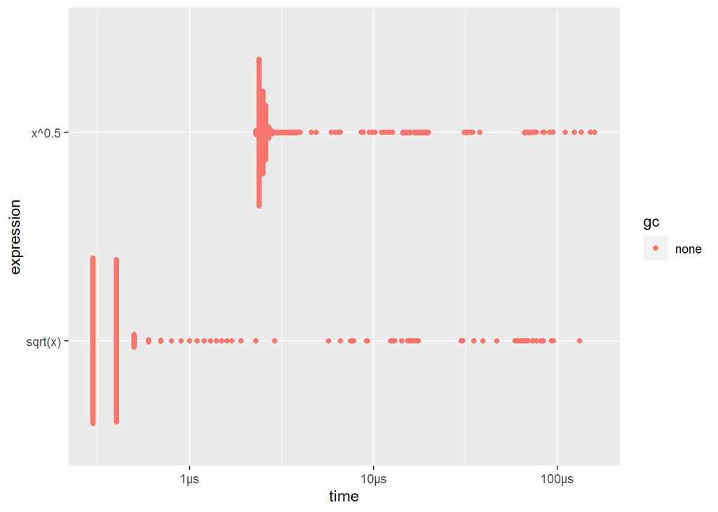

```r
plot(lb)
```

```r
lb[c("expression", "min", "median", "itr/sec", "n_gc")]
```

```
## # A tibble: 2 × 4
##   expression      min   median `itr/sec`
##   <bch:expr> <bch:tm> <bch:tm>     <dbl>
## 1 sqrt(x)       300ns    400ns  1568431.
## 2 x^0.5         2.3µs    2.5µs   330422.
```

### 23.3.2 Interpreting results

### 23.3.3 Exercises

1. Instead of using `bench::mark()`, you could use the built-in function `system.time()`. But `system.time()` is much less precise, so you’ll need to repeat each operation many times with a loop, and then divide to find the average time of each operation, as in the code below.

```r
n <- 1e6
system.time(for (i in 1:n) sqrt(x)) / n
```

```
##    user  system elapsed
## 5.3e-07 8.0e-08 6.1e-07
```

```r
system.time(for (i in 1:n) x ^ 0.5) / n
```

```
##     user   system  elapsed
## 2.86e-06 0.00e+00 2.86e-06
```

How do the estimates from `system.time()` compare to those from `bench::mark()`? Why are they different?

```r
x <- runif(100)
n <- 1e6

system_a <- system.time(for (i in 1:n) sqrt(x)) / n
system_a <- system_a[3]

system_b <- system.time(for (i in 1:n) x ^ 0.5) / n
system_b <- system_b[3]

lb <- bench::mark(
  sqrt(x),
  x ^ 0.5
)

bench_a <- mean(unlist(lb[1,"time"]))
bench_b <- mean(unlist(lb[2,"time"]))

data.frame(bench = c(bench_a, bench_b),
           BaseR = c(system_a, system_b))
```

```
##         bench    BaseR
## 1 3.98640e-07 4.80e-07
## 2 2.85846e-06 2.84e-06
```

The exponential function is about the same, but the sqrt function is slower in the loop. Magnitude is the same though.

2. Here are two other ways to compute the square root of a vector. Which do you think will be fastest? Which will be slowest? Use microbenchmarking to test your answers.

```r
x ^ (1 / 2) # Slower
```

```
##   [1] 0.6004734 0.4210441 0.7132367 0.4052539 0.8604020 0.8597028 0.9953350
##   [8] 0.7287609 0.7795585 0.8158131 0.7015178 0.4540966 0.8648031 0.5246405
##  [15] 0.5240490 0.1832683 0.9892300 0.7819322 0.8278856 0.6620922 0.3169671
##  [22] 0.2839073 0.6963421 0.9938103 0.3866772 0.2598348 0.4224345 0.2943808
##  [29] 0.9663313 0.4980089 0.2950804 0.6109725 0.2730500 0.6548038 0.7447416
##  [36] 0.7106090 0.5565286 0.2642540 0.6311000 0.7548540 0.7714136 0.9600486
##  [43] 0.8049826 0.9761485 0.9114274 0.7438724 0.8782844 0.1186766 0.1515044
##  [50] 0.9891991 0.4260723 0.8966773 0.4125705 0.7502701 0.6728621 0.8337686
##  [57] 0.5029102 0.3471324 0.6605282 0.8888308 0.7068626 0.5539709 0.5422343
##  [64] 0.7694977 0.5219256 0.6091366 0.3042176 0.7855986 0.8131432 0.3674737
##  [71] 0.9294045 0.8253283 0.9851643 0.5276412 0.8450047 0.7958893 0.4993799
##  [78] 0.8080481 0.5793697 0.3458965 0.7292231 0.5511298 0.6902232 0.9579442
##  [85] 0.7531414 0.5277562 0.4454646 0.5347170 0.8804140 0.7118378 0.8203565
##  [92] 0.4548480 0.8751034 0.2568453 0.8584669 0.3476022 0.7115730 0.9292685
##  [99] 0.3208887 0.8297652
```

```r
exp(log(x) / 2) # Faster
```

```
##   [1] 0.6004734 0.4210441 0.7132367 0.4052539 0.8604020 0.8597028 0.9953350
##   [8] 0.7287609 0.7795585 0.8158131 0.7015178 0.4540966 0.8648031 0.5246405
##  [15] 0.5240490 0.1832683 0.9892300 0.7819322 0.8278856 0.6620922 0.3169671
##  [22] 0.2839073 0.6963421 0.9938103 0.3866772 0.2598348 0.4224345 0.2943808
##  [29] 0.9663313 0.4980089 0.2950804 0.6109725 0.2730500 0.6548038 0.7447416
##  [36] 0.7106090 0.5565286 0.2642540 0.6311000 0.7548540 0.7714136 0.9600486
##  [43] 0.8049826 0.9761485 0.9114274 0.7438724 0.8782844 0.1186766 0.1515044
##  [50] 0.9891991 0.4260723 0.8966773 0.4125705 0.7502701 0.6728621 0.8337686
##  [57] 0.5029102 0.3471324 0.6605282 0.8888308 0.7068626 0.5539709 0.5422343
##  [64] 0.7694977 0.5219256 0.6091366 0.3042176 0.7855986 0.8131432 0.3674737
##  [71] 0.9294045 0.8253283 0.9851643 0.5276412 0.8450047 0.7958893 0.4993799
##  [78] 0.8080481 0.5793697 0.3458965 0.7292231 0.5511298 0.6902232 0.9579442
##  [85] 0.7531414 0.5277562 0.4454646 0.5347170 0.8804140 0.7118378 0.8203565
##  [92] 0.4548480 0.8751034 0.2568453 0.8584669 0.3476022 0.7115730 0.9292685
##  [99] 0.3208887 0.8297652
```

```r
lb <- bench::mark(
  sqrt(x), # 1
  x ^ 0.5, # 2
  x ^ (1 / 2), # 3
  exp(log(x) / 2) # 4
)

lb[c("expression", "min", "median", "itr/sec", "n_gc")] %>%
  arrange(3)
```

```
## # A tibble: 4 × 4
##   expression         min   median `itr/sec`
##   <bch:expr>    <bch:tm> <bch:tm>     <dbl>
## 1 sqrt(x)          300ns    400ns  2381236.
## 2 x^0.5            2.3µs    2.5µs   363957.
## 3 x^(1/2)          2.4µs    2.6µs   348321.
## 4 exp(log(x)/2)    5.9µs    6.2µs   149988.
```

`sqrt` function is optimized, then each function after it is adding one more call to the calculation which slows it down further.